# R Notebook

#### 3.1.2 K = 3

```r
# temporal clustering setup
# sliding window size 3 instead of expanding by 1

set.seed(1234)

k <- 3
window_size <- 3
threshold_1 <- -3
threshold_2 <- -5

n_pts_filtered <- nrow(cadia_D_filtered_sliding)
n_dates_filtered <- ncol(cadia_D_filtered_sliding)

# number of overlapping sliding windows
n_iters_filtered <- n_dates_filtered - window_size + 1

# date representing each window = final date in window
iter_dates_filtered <- colnames(cadia_D_filtered_sliding)[
  window_size:n_dates_filtered
]
```

```r
# membership matrix
cluster_membership_mat_sliding_k3 <- matrix(
  NA,
  nrow = n_pts_filtered,
  ncol = n_iters_filtered
)

colnames(cluster_membership_mat_sliding_k3) <- paste0(
  "cluster_",
  sub("^D_", "", iter_dates_filtered)
)
```

```r
# status matrix
cluster_status_mat_sliding_k3 <- matrix(
  NA,
  nrow = n_pts_filtered,
  ncol = n_iters_filtered
)

colnames(cluster_status_mat_sliding_k3) <- paste0(
  "cluster_",
  sub("^D_", "", iter_dates_filtered)
)
```

```r
# medians matrix
cluster_medians_mat_sliding_k3 <- matrix(
  NA,
  nrow = n_iters_filtered,
  ncol = k
)

colnames(cluster_medians_mat_sliding_k3) <- c(
  "Lower median",
  "Middle median",
  "Higher median"
)
```

```r
silhouette_disp_k3_w3 <- numeric(n_iters_filtered)
```

```r
n_iters_filtered
```

```
[1] 43
```

```r
ncol(cluster_membership_mat_sliding_k2)
```

```
[1] 43
```

```r
length(iter_dates_filtered)
```

```
[1] 43
```

```r
# temporal clustering loop

for (i in window_size:n_dates_filtered) {

  start_idx <- i - window_size + 1

  x <- cadia_D_filtered_sliding[
    , start_idx:i,
    drop = FALSE
  ]

  # reset each pt to 0 at the start of each window
  x <- sweep(
    x,
    1,
    x[, 1],
    FUN = "-"
  )

  km <- kmeans(
    x,
    centers = k,
    nstart = 20
  )

  # displacement at newest date
  latest_disp <- x[, ncol(x)]

  # current iteration number
  iter <- i - window_size + 1

  sil <- cluster::silhouette(
  km$cluster,
  dist(x)
  )

  silhouette_disp_k3_w3[iter] <- mean(
    sil[, "sil_width"]
  )

  # store raw cluster membership
  cluster_membership_mat_sliding_k3[
    , iter
  ] <- km$cluster

  # median newest displacement
  # for each raw cluster
  cluster_medians <- tapply(
    latest_disp,
    km$cluster,
    median
  )

  # ordered medians only for plotting
  ordered_medians <- sort(
    cluster_medians
  )

  cluster_medians_mat_sliding_k3[
    iter,
  ] <- ordered_medians

  # classify each raw K-means cluster
  cluster_status <- ifelse(
    cluster_medians <= threshold_2,
    2,
    ifelse(
      cluster_medians <= threshold_1,
      1,
      0
    )
  )

  # each point inherits the status of its cluster
  pt_status <- cluster_status[
    as.character(km$cluster)
  ]

  cluster_status_mat_sliding_k3[
    , iter
  ] <- pt_status

}
```

```r
head(cluster_medians_mat_sliding_k3)
```

```
     Lower median Middle median Higher median
[1,]        -3.00           0.5          5.00
[2,]        -5.10          -0.1          3.10
[3,]        -4.15          -0.7          2.50
[4,]        -3.80          -0.1          5.80
[5,]        -3.60          -0.5          2.30
[6,]        -3.50          -0.1          5.05
```

```r
tail(cluster_medians_mat_sliding_k3)
```

```
      Lower median Middle median Higher median
[38,]        -7.00          -0.9           9.7
[39,]        -8.90          -1.1           9.2
[40,]        -7.40           0.2           7.7
[41,]        -6.50           1.7           9.9
[42,]        -7.15           0.2          10.4
[43,]        -7.70           0.3          10.5
```

```r
summary(cluster_medians_mat_sliding_k3)
```

```
  Lower median    Middle median     Higher median
 Min.   :-8.900   Min.   :-1.2000   Min.   : 1.500
 1st Qu.:-5.100   1st Qu.:-0.7500   1st Qu.: 2.800
 Median :-4.100   Median :-0.2000   Median : 4.000
 Mean   :-4.498   Mean   :-0.2244   Mean   : 5.101
 3rd Qu.:-3.250   3rd Qu.: 0.2000   3rd Qu.: 7.650
 Max.   :-2.100   Max.   : 1.7000   Max.   :10.500
```

```r
dim(cluster_membership_mat_sliding_k2)
dim(cluster_status_mat_sliding_k2)
dim(cluster_medians_mat_sliding_k2)
```

We check the medians from the initial test to choose an appropriate threshold.

```r
head(cluster_medians_mat_sliding_k2)
```

```
     Lower median Higher median
[1,]         -1.0          1.90
[2,]         -1.8          1.80
[3,]         -1.9          0.30
[4,]         -2.4          1.00
[5,]         -1.5          0.50
[6,]         -1.8          1.25
```

```r
tail(cluster_medians_mat_sliding_k2)
```

```
      Lower median Higher median
[38,]         -2.2           7.2
[39,]         -3.1           3.4
[40,]         -3.0           2.1
[41,]         -3.1           4.2
[42,]         -4.2           1.9
[43,]         -2.1           6.6
```

```r
summary(cluster_medians_mat_sliding_k2)
```

[output not shown]

```r
thresholds <- c(-2, -2.5, -3, -3.5, -4, -5)

threshold_check <- data.frame(
  Threshold = thresholds,
  WindowsFlagged = sapply(
    thresholds,
    function(th) {
      sum(lower_med <= th, na.rm = TRUE)
    }
  )
)

threshold_check
```

| Threshold | WindowsFlagged |
| --- | --- |
| -2.0 | 20 |
| -2.5 | 8 |
| -3.0 | 5 |
| -3.5 | 2 |
| -4.0 | 2 |
| -5.0 | 1 |

```r
table(cluster_status_mat_sliding_k3)
```

```
cluster_status_mat_sliding_k3
    0     1     2
88882 13039  5364
```

```r
status_counts_k3 <- t(
  apply(
    cluster_status_mat_sliding_k3,
    2,
    function(x) table(
      factor(x, levels = c(0, 1, 2))
    )
  )
)

colnames(status_counts_k3) <- c(
  "Status0",
  "Status1",
  "Status2"
)

status_counts_k3
```

```
                 Status0 Status1 Status2
cluster_20161015    1992     503       0
cluster_20161021    2194       0     301
cluster_20161102    2249     246       0
cluster_20161114    1798     697       0
cluster_20161126    2171     324       0
cluster_20161208    1967     528       0
cluster_20161220    2200     295       0
cluster_20170101    2082     413       0
cluster_20170113    1975     520       0
cluster_20170125    2495       0       0
cluster_20170206    2044     451       0
cluster_20170218    1850     645       0
cluster_20170302    2009     486       0
cluster_20170314    2030     465       0
cluster_20170326    1950     545       0
cluster_20170407    2004     491       0
cluster_20170419    1875     620       0
cluster_20170501    1882     613       0
cluster_20170513    1905     590       0
cluster_20170525    2161     334       0
cluster_20170606    2495       0       0
cluster_20170618    1977     518       0
cluster_20170630    1893     602       0
cluster_20170712    2495       0       0
cluster_20170724    2119     376       0
cluster_20170805    2495       0       0
cluster_20170817    2261       0     234
cluster_20170829    2495       0       0
cluster_20170910    1779     716       0
cluster_20170922    2339       0     156
cluster_20171004    2124     371       0
cluster_20171016    2026     469       0
cluster_20171028    1887     608       0
cluster_20171109    1882     613       0
cluster_20171121    2017       0     478
cluster_20171203    1951       0     544
cluster_20171215    2115       0     380
cluster_20171227    1931       0     564
cluster_20180108    2020       0     475
cluster_20180120    2043       0     452
cluster_20180201    1879       0     616
cluster_20180213    1933       0     562
cluster_20180225    1893       0     602
```

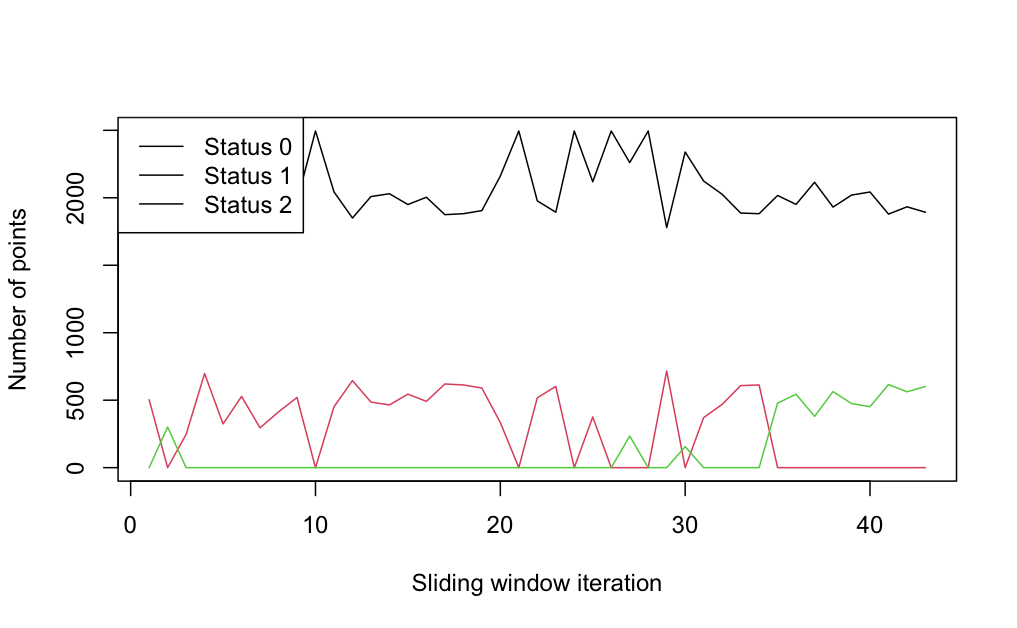

```r
matplot(
  status_counts_k3,
  type = "l",
  lty = 1,
  xlab = "Sliding window iteration",
  ylab = "Number of points"
)

legend(
  "topleft",
  legend = c(
    "Status 0",
    "Status 1",
    "Status 2"
  ),
  lty = 1
)
```

##### Exporting

```r
# cluster membership conversion
cadia_sliding_clusters_df_k3 <-
  as.data.frame(cluster_membership_mat_sliding_k3)

cadia_sliding_clusters_df_k3$PointID <-
  cadia_info_sliding$PointID

cadia_sliding_clusters_long_k3 <-
  cadia_sliding_clusters_df_k3 %>%
  pivot_longer(
    cols = -PointID,
    names_to = "Date",
    values_to = "RawCluster"
  )
```

```r
# status conversion
cadia_sliding_status_df_k3 <-
  as.data.frame(cluster_status_mat_sliding_k3)

cadia_sliding_status_df_k3$PointID <-
  cadia_info_sliding$PointID

cadia_sliding_status_long_k3 <-
  cadia_sliding_status_df_k3 %>%
  pivot_longer(
    cols = -PointID,
    names_to = "Date",
    values_to = "Status"
  )
```

```r
# combine membership + status
cadia_sliding_results_k3 <-
  cadia_sliding_clusters_long_k3 %>%
  left_join(
    cadia_sliding_status_long_k3,
    by = c("PointID", "Date")
  )
```

```r
cadia_sliding_results_k3 <-
  cadia_sliding_results_k3 %>%
  mutate(
    Date = sub("^cluster_", "", Date),
    Date = as.Date(Date, format = "%Y%m%d")
  )
```

```r
# join other data
cadia_sliding_results_k3 <-
  cadia_sliding_results_k3 %>%
  left_join(
    cadia_info_sliding,
    by = "PointID"
  )
```

```r
names(cadia_sliding_results_k3)
```

```
[1] "PointID"    "Date"       "RawCluster" "Status"     "lon"        "lat"        "coherence"
```

```r
head(cadia_sliding_results_k3)
```

| PointID | Date | RawCluster | Status | lon | lat | coherence |
| --- | --- | --- | --- | --- | --- | --- |
| 1 | 2016-10-15 | 1 | 0 | 148.9938 | -33.49118 | 0.796 |
| 1 | 2016-10-21 | 1 | 0 | 148.9938 | -33.49118 | 0.796 |
| 1 | 2016-11-02 | 3 | 0 | 148.9938 | -33.49118 | 0.796 |
| 1 | 2016-11-14 | 3 | 1 | 148.9938 | -33.49118 | 0.796 |
| 1 | 2016-11-26 | 2 | 0 | 148.9938 | -33.49118 | 0.796 |
| 1 | 2016-12-08 | 1 | 0 | 148.9938 | -33.49118 | 0.796 |

```r
# export
write.csv(
  cadia_sliding_results_k3,
  "../outputs/cadia_sliding_k3_w3_thresholds3_5.csv",
  row.names = FALSE
)
```

##### Results check

1. How many points are flagged at each iteration?

```r
flagged_per_iter <- colSums(
  cluster_status_mat_sliding_k2 == 1,
  na.rm = TRUE
)

flagged_per_iter
```

[output not shown]

```r
plot(
  flagged_per_iter,
  type = "l",
  xlab = "Sliding window iteration",
  ylab = "Number of flagged points"
)
```

```r
# check matrix
table(cluster_status_mat_sliding_k2, useNA = "ifany")
```

### 3.2 Median Velocity Version

#### 3.2.1 K = 2

```r
# setup
set.seed(1234)

k <- 2
window_size <- 3
velocity_threshold <- -25

n_pts_filtered <- nrow(cadia_D_filtered_sliding)
n_dates_filtered <- ncol(cadia_D_filtered_sliding)

n_iters_filtered <-
  n_dates_filtered - window_size + 1

iter_dates_filtered <-
  colnames(cadia_D_filtered_sliding)[
    window_size:n_dates_filtered
  ]
```

```r
cadia_all_dates <- as.Date(
  sub("^D_", "", colnames(cadia_D_filtered_sliding)),
  format = "%Y%m%d"
)
```

```r
head(cadia_all_dates)
```

```
[1] "2016-09-27" "2016-10-09" "2016-10-15" "2016-10-21" "2016-11-02" "2016-11-14"
```

```r
diff(cadia_all_dates)
```

```
Time differences in days
 [1] 12  6  6 12 12 12 12 12 12 12 12 12 12 12 12 12 12 12 12 12 12 12 12 12 12 12 12 12 12 12 12 12 12 12 12 12 12 12 12 12 12 12 12 12
```

```r
# membership matrix
cluster_membership_mat_velocity_k2 <- matrix(
  NA,
  nrow = n_pts_filtered,
  ncol = n_iters_filtered
)

colnames(cluster_membership_mat_velocity_k2) <- paste0(
  "cluster_",
  sub("^D_", "", iter_dates_filtered)
)
```

```r
cluster_status_mat_velocity_k2 <- matrix(
  NA,
  nrow = n_pts_filtered,
  ncol = n_iters_filtered
)

colnames(cluster_status_mat_velocity_k2) <-
  colnames(cluster_membership_mat_velocity_k2)
```

```r
# median matrix
cluster_velocity_mat_k2 <- matrix(
  NA,
  nrow = n_iters_filtered,
  ncol = k
)

colnames(cluster_velocity_mat_k2) <- c(
  "Lower velocity",
  "Higher velocity"
)
```

```r
silhouette_vel_k2_w3_old <- numeric(n_iters_filtered)
```

```r
# temporal clustering loop - velocity version

for (i in window_size:n_dates_filtered) {

  start_idx <- i - window_size + 1

  # current 3-date displacement window
  x <- cadia_D_filtered_sliding[
    , start_idx:i,
    drop = FALSE
  ]

  # reset each point to 0 at start of window
  x <- sweep(
    x,
    1,
    x[, 1],
    FUN = "-"
  )

  # dates in current window
  window_dates <- cadia_all_dates[start_idx:i]

  # time from start of window in days
  time_days <- as.numeric(
    window_dates - window_dates[1]
  )

  # K-means on displacement trajectories
  km <- kmeans(
    x,
    centers = k,
    nstart = 20
  )

  # iteration number
  iter <- i - window_size + 1

  sil <- cluster::silhouette(
  km$cluster,
  dist(x)
  )

  silhouette_vel_k2_w3_old[iter] <- mean(sil[, "sil_width"])

  # store raw cluster membership
  cluster_membership_mat_velocity_k2[
    , iter
  ] <- km$cluster

  # velocity for each individual point
  point_velocity <- apply(
    x,
    1,
    function(y) {
      coef(lm(y ~ time_days))[2]
    }
  )

  # mm/day -> mm/year
  point_velocity <- point_velocity * 365.25

  # median velocity for each raw K-means cluster
  cluster_velocities <- tapply(
    point_velocity,
    km$cluster,
    median
  )

  # ordered values just for plotting/inspection
  ordered_velocities <- sort(
    cluster_velocities
  )

  cluster_velocity_mat_k2[
    iter,
  ] <- ordered_velocities

  # classify each K-means cluster using fixed velocity threshold
  cluster_status <- ifelse(
    cluster_velocities <= velocity_threshold,
    1,   # concerning negative velocity
    0    # non-concerning
  )

  # every point inherits the status of its K-means cluster
  pt_status <- cluster_status[
    as.character(km$cluster)
  ]

  # store point status
  cluster_status_mat_velocity_k2[
    , iter
  ] <- pt_status
}
```

Inspect velocity results:

```r
head(cluster_velocity_mat_k2)
```

```
     Lower velocity Higher velocity
[1,]      -20.87143       42.177679
[2,]      -54.78750       54.787500
[3,]      -31.52455       -1.304464
[4,]      -36.52500       15.218750
[5,]      -22.82813        7.609375
[6,]      -27.39375       19.023438
```

```r
tail(cluster_velocity_mat_k2)
```

```
      Lower velocity Higher velocity
[38,]      -33.48125       109.57500
[39,]      -47.17813        51.74375
[40,]      -45.65625        31.95938
[41,]      -47.17812        63.91875
[42,]      -63.91875        28.91563
[43,]      -31.95938       100.44375
```

```r
summary(cluster_velocity_mat_k2)
```

```
 Lower velocity   Higher velocity
 Min.   :-85.22   Min.   : -1.304
 1st Qu.:-36.52   1st Qu.: 12.936
 Median :-30.44   Median : 21.306
 Mean   :-31.44   Mean   : 30.432
 3rd Qu.:-22.83   3rd Qu.: 36.525
 Max.   :  0.00   Max.   :109.575
```

```r
matplot(
  cluster_velocity_mat_k2,
  type = "l",
  lty = 1,
  xlab = "Sliding window iteration",
  ylab = "Median LOS velocity (mm/year)"
)

abline(h = 0, lty = 2)
```

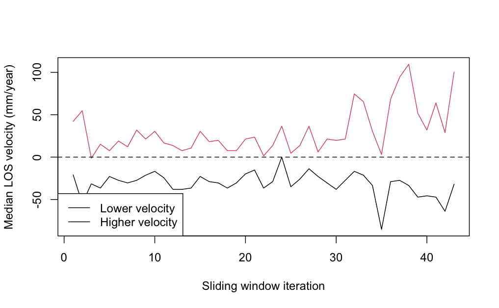

```r
legend(
  "bottomleft",
  legend = colnames(cluster_velocity_mat_k2),
  lty = 1
)
```

```r
table(cluster_status_mat_velocity_k2)
```

```
cluster_status_mat_velocity_k2
    0     1
66836 40449
```

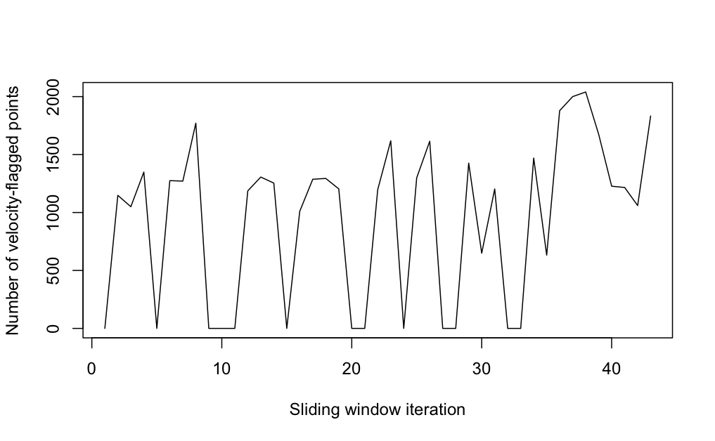

```r
flagged_velocity <- colSums(
  cluster_status_mat_velocity_k2 == 1,
  na.rm = TRUE
)

plot(
  flagged_velocity,
  type = "l",
  xlab = "Sliding window iteration",
  ylab = "Number of velocity-flagged points"
)
```

```r
velocity_flag_check <- data.frame(
  Date = iter_dates_filtered,
  LowerVelocity = cluster_velocity_mat_k2[, 1],
  HigherVelocity = cluster_velocity_mat_k2[, 2],
  FlaggedPoints = flagged_velocity
)

velocity_flag_check
```

|  | Date | LowerVelocity | HigherVelocity | FlaggedPoints |
| --- | --- | --- | --- | --- |
| cluster_20161015 | D_20161015 | -2.087143e+01 | 42.177679 | 0 |
| cluster_20161021 | D_20161021 | -5.478750e+01 | 54.787500 | 1148 |
| cluster_20161102 | D_20161102 | -3.152455e+01 | -1.304464 | 1050 |
| cluster_20161114 | D_20161114 | -3.652500e+01 | 15.218750 | 1349 |
| cluster_20161126 | D_20161126 | -2.282813e+01 | 7.609375 | 0 |
| cluster_20161208 | D_20161208 | -2.739375e+01 | 19.023438 | 1275 |
| cluster_20161220 | D_20161220 | -3.043750e+01 | 12.175000 | 1271 |
| cluster_20170101 | D_20170101 | -2.739375e+01 | 31.959375 | 1771 |
| cluster_20170113 | D_20170113 | -2.130625e+01 | 21.306250 | 0 |
| cluster_20170125 | D_20170125 | -1.674063e+01 | 30.437500 | 0 |

[output cut: 33 more lines]

```r
dim(cluster_membership_mat_velocity_k2)
```

```
[1] 2495   43
```

```r
dim(cluster_status_mat_velocity_k2)
```

```
[1] 2495   43
```

```r
table(cluster_status_mat_velocity_k2)
```

```
cluster_status_mat_velocity_k2
    0     1
66836 40449
```

```r
head(colnames(cluster_status_mat_velocity_k2))
```

```
[1] "cluster_20161015" "cluster_20161021" "cluster_20161102" "cluster_20161114" "cluster_20161126" "cluster_20161208"
```

```r
head(colnames(cluster_membership_mat_velocity_k2))
```

```
[1] "cluster_20161015" "cluster_20161021" "cluster_20161102" "cluster_20161114" "cluster_20161126" "cluster_20161208"
```

##### Exporting:

```r
cadia_info_velocity <- cadia_co_filtered %>%
  select(
    PointID,
    lon,
    lat,
    coherence
  )
```

```r
nrow(cadia_info_velocity)
```

```
[1] 2495
```

```r
nrow(cluster_membership_mat_velocity_k2)
```

```
[1] 2495
```

```r
# convert clusters
cadia_velocity_clusters_df <-
  as.data.frame(cluster_membership_mat_velocity_k2)

cadia_velocity_clusters_df$PointID <-
  cadia_info_velocity$PointID
```

```r
cadia_velocity_clusters_long <-
  cadia_velocity_clusters_df %>%
  pivot_longer(
    cols = -PointID,
    names_to = "Date",
    values_to = "RawCluster"
  )
```

```r
# convert status
cadia_velocity_status_df <-
  as.data.frame(cluster_status_mat_velocity_k2)

cadia_velocity_status_df$PointID <-
  cadia_info_velocity$PointID
```

```r
cadia_velocity_status_long <-
  cadia_velocity_status_df %>%
  pivot_longer(
    cols = -PointID,
    names_to = "Date",
    values_to = "Status"
  )
```

```r
# combine clusters and status
cadia_velocity_results <-
  cadia_velocity_clusters_long %>%
  left_join(
    cadia_velocity_status_long,
    by = c("PointID", "Date")
  )
```

```r
head(cadia_velocity_results)
```

| PointID | Date | RawCluster | Status |
| --- | --- | --- | --- |
| 1 | cluster_20161015 | 1 | 0 |
| 1 | cluster_20161021 | 1 | 0 |
| 1 | cluster_20161102 | 1 | 0 |
| 1 | cluster_20161114 | 2 | 1 |
| 1 | cluster_20161126 | 2 | 0 |
| 1 | cluster_20161208 | 2 | 0 |

```r
names(cadia_velocity_results)
```

```
[1] "PointID"    "Date"       "RawCluster" "Status"
```

```r
# convert the dates
cadia_velocity_results <-
  cadia_velocity_results %>%
  mutate(
    Date = sub("^cluster_", "", Date),
    Date = as.Date(
      Date,
      format = "%Y%m%d"
    )
  )
```

```r
head(cadia_velocity_results$Date)
```

```
[1] "2016-10-15" "2016-10-21" "2016-11-02" "2016-11-14" "2016-11-26" "2016-12-08"
```

```r
str(cadia_velocity_results$Date)
```

```
 Date[1:107285], format: "2016-10-15" "2016-10-21" "2016-11-02" "2016-11-14" "2016-11-26" "2016-12-08" "2016-12-20" "2017-01-01" "2017-01-13" "2017-01-25" "2017-02-06" "2017-02-18" "2017-03-02" "2017-03-14" "2017-03-26" ...
```

```r
# join other info
cadia_velocity_results <-
  cadia_velocity_results %>%
  left_join(
    cadia_info_velocity,
    by = "PointID"
  )
```

```r
names(cadia_velocity_results)
```

```r
head(cadia_velocity_results)
summary(cadia_velocity_results$Status)
```

```r
length(unique(cadia_velocity_results$PointID))
length(unique(cadia_velocity_results$Date))
table(cadia_velocity_results$Status)
```

```r
write.csv(
  cadia_velocity_results,
  "../outputs/cadia_sliding_velocity_k2_w3_threshold25.csv",
  row.names = FALSE
)
```

#### 3.2.2 K = 3

```r
set.seed(1234)

k <- 3
window_size <- 3
threshold_1 <- -25
threshold_2 <- -75

n_pts_filtered <- nrow(cadia_D_filtered_sliding)
n_dates_filtered <- ncol(cadia_D_filtered_sliding)

n_iters_filtered <-
  n_dates_filtered - window_size + 1

iter_dates_filtered <-
  colnames(cadia_D_filtered_sliding)[
    window_size:n_dates_filtered
  ]

cadia_all_dates <- as.Date(
  sub("^D_", "", colnames(cadia_D_filtered_sliding)),
  format = "%Y%m%d"
)
```

```r
cluster_membership_mat_velocity_k3 <- matrix(
  NA,
  nrow = n_pts_filtered,
  ncol = n_iters_filtered
)

colnames(cluster_membership_mat_velocity_k3) <- paste0(
  "cluster_",
  sub("^D_", "", iter_dates_filtered)
)
```

```r
cluster_status_mat_velocity_k3 <- matrix(
  NA,
  nrow = n_pts_filtered,
  ncol = n_iters_filtered
)

colnames(cluster_status_mat_velocity_k3) <-
  colnames(cluster_membership_mat_velocity_k3)
```

```r
cluster_velocity_mat_k3 <- matrix(
  NA,
  nrow = n_iters_filtered,
  ncol = k
)

colnames(cluster_velocity_mat_k3) <- c(
  "Lower velocity",
  "Middle velocity",
  "Higher velocity"
)
```

```r
silhouette_vel_k3_w3_old <- numeric(n_iters_filtered)
```

```r
for (i in window_size:n_dates_filtered) {

  start_idx <- i - window_size + 1

  # extract current 3-date window
  x <- cadia_D_filtered_sliding[
    , start_idx:i,
    drop = FALSE
  ]

  # reset each point to 0 at start of window
  x <- sweep(
    x,
    1,
    x[, 1],
    FUN = "-"
  )

  # dates for current window
  window_dates <- cadia_all_dates[start_idx:i]

  # time in days from start of window
  time_days <- as.numeric(
    window_dates - window_dates[1]
  )

  # K-means on rebased displacement
  km <- kmeans(
    x,
    centers = k,
    nstart = 20
  )

  iter <- i - window_size + 1

  sil <- cluster::silhouette(
    km$cluster,
    dist(x)
  )

  silhouette_vel_k3_w3_old[iter] <- mean(sil[, "sil_width"])

  # store RAW K-means membership
  cluster_membership_mat_velocity_k3[
    , iter
  ] <- km$cluster

  # velocity of each individual point
  point_velocity <- apply(
    x,
    1,
    function(y) {
      coef(lm(y ~ time_days))[2]
    }
  )

  # mm/day -> mm/year
  point_velocity <- point_velocity * 365.25

  # median velocity of each raw K-means cluster
  cluster_velocities <- tapply(
    point_velocity,
    km$cluster,
    median
  )

  # sort ONLY for inspection
  ordered_velocities <- sort(
    cluster_velocities
  )

  cluster_velocity_mat_k3[
    iter,
  ] <- ordered_velocities

  # classify raw clusters by median velocity
  cluster_status <- ifelse(
    cluster_velocities <= threshold_2,
    2,
    ifelse(
      cluster_velocities <= threshold_1,
      1,
      0
    )
  )

  # each point inherits its cluster's status
  pt_status <- cluster_status[
    as.character(km$cluster)
  ]

cluster_status_mat_velocity_k3[
  , iter
] <- pt_status
}
```

```r
head(cluster_velocity_mat_k3)
```

```
     Lower velocity Middle velocity Higher velocity
[1,]      -64.78839        9.566071       109.57500
[2,]     -155.23125       -3.043750        94.35625
[3,]      -63.48393      -14.783929        30.87232
[4,]      -57.83125       -1.521875        88.26875
[5,]      -54.78750       -7.609375        35.00312
[6,]      -53.26562       -1.521875        76.85469
```

```r
tail(cluster_velocity_mat_k3)
```

```
      Lower velocity Middle velocity Higher velocity
[38,]     -106.53125      -13.696875        147.6219
[39,]     -135.44688      -16.740625        140.0125
[40,]     -112.61875        3.043750        117.1844
[41,]      -98.92188       25.871875        150.6656
[42,]     -108.81406        3.043750        158.2750
[43,]     -117.18438        4.565625        159.7969
```

```r
summary(cluster_velocity_mat_k3)
```

```
 Lower velocity    Middle velocity   Higher velocity
 Min.   :-155.23   Min.   :-18.262   Min.   : 22.83
 1st Qu.: -85.22   1st Qu.:-12.175   1st Qu.: 42.61
 Median : -63.48   Median : -3.044   Median : 60.88
 Mean   : -70.71   Mean   : -3.501   Mean   : 79.34
 3rd Qu.: -50.22   3rd Qu.:  3.044   3rd Qu.:116.42
 Max.   : -31.96   Max.   : 25.872   Max.   :159.80
```

```r
matplot(
  cluster_velocity_mat_k3,
  type = "l",
  lty = 1,
  xlab = "Sliding window iteration",
  ylab = "Median LOS velocity (mm/year)"
)

abline(h = 0, lty = 2)

legend(
  "bottomleft",
  legend = colnames(cluster_velocity_mat_k3),
  lty = 1
)
```

```r
table(cluster_status_mat_velocity_k3)
```

```
cluster_status_mat_velocity_k3
    0     1     2
86183 15738  5364
```

```r
status_counts_velocity_k3 <- t(
  apply(
    cluster_status_mat_velocity_k3,
    2,
    function(x) {
      table(
        factor(x, levels = c(0, 1, 2))
      )
    }
  )
)

colnames(status_counts_velocity_k3) <-
  c("Status0", "Status1", "Status2")

status_counts_velocity_k3
```

```
                 Status0 Status1 Status2
cluster_20161015    1992     503       0
cluster_20161021    2194       0     301
cluster_20161102    2249     246       0
cluster_20161114    1798     697       0
cluster_20161126    2171     324       0
cluster_20161208    1967     528       0
cluster_20161220    2200     295       0
cluster_20170101    2082     413       0
cluster_20170113    1975     520       0
cluster_20170125    1997     498       0
cluster_20170206    2044     451       0
cluster_20170218    1850     645       0
cluster_20170302    2009     486       0
cluster_20170314    2030     465       0
cluster_20170326    1950     545       0
cluster_20170407    2004     491       0
cluster_20170419    1875     620       0
cluster_20170501    1882     613       0
cluster_20170513    1905     590       0
cluster_20170525    2161     334       0
cluster_20170606    1954     541       0
cluster_20170618    1977     518       0
cluster_20170630    1893     602       0
cluster_20170712    2089     406       0
cluster_20170724    2119     376       0
cluster_20170805    1764     731       0
cluster_20170817    2261       0     234
cluster_20170829    1972     523       0
cluster_20170910    1779     716       0
cluster_20170922    2339       0     156
cluster_20171004    2124     371       0
cluster_20171016    2026     469       0
cluster_20171028    1887     608       0
cluster_20171109    1882     613       0
cluster_20171121    2017       0     478
cluster_20171203    1951       0     544
cluster_20171215    2115       0     380
cluster_20171227    1931       0     564
cluster_20180108    2020       0     475
cluster_20180120    2043       0     452
cluster_20180201    1879       0     616
cluster_20180213    1933       0     562
cluster_20180225    1893       0     602
```

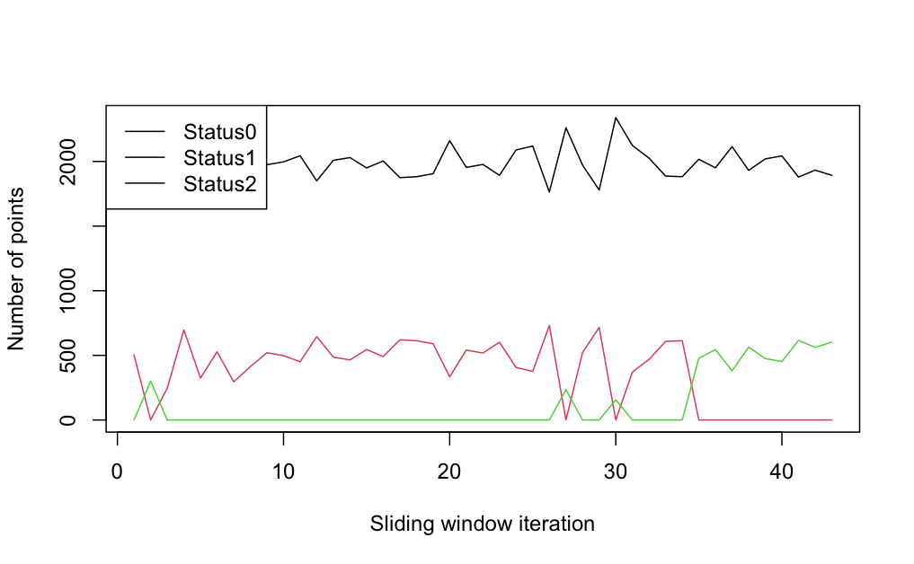

```r
matplot(
  status_counts_velocity_k3,
  type = "l",
  lty = 1,
  xlab = "Sliding window iteration",
  ylab = "Number of points"
)

legend(
  "topleft",
  legend = colnames(status_counts_velocity_k3),
  lty = 1
)
```

```r
# convert clusters
cadia_velocity_clusters_df_k3 <-
  as.data.frame(cluster_membership_mat_velocity_k3)

cadia_velocity_clusters_df_k3$PointID <-
  cadia_info_velocity$PointID

cadia_velocity_clusters_long_k3 <-
  cadia_velocity_clusters_df_k3 %>%
  pivot_longer(
    cols = -PointID,
    names_to = "Date",
    values_to = "RawCluster"
  )
```

```r
# convert status
cadia_velocity_status_df_k3 <-
  as.data.frame(cluster_status_mat_velocity_k3)

cadia_velocity_status_df_k3$PointID <-
  cadia_info_velocity$PointID

cadia_velocity_status_long_k3 <-
  cadia_velocity_status_df_k3 %>%
  pivot_longer(
    cols = -PointID,
    names_to = "Date",
    values_to = "Status"
  )
```

```r
# join cluster and status
cadia_velocity_results_k3 <-
  cadia_velocity_clusters_long_k3 %>%
  left_join(
    cadia_velocity_status_long_k3,
    by = c("PointID", "Date")
  )
```

```r
cadia_velocity_results_k3 <-
  cadia_velocity_results_k3 %>%
  mutate(
    Date = sub("^cluster_", "", Date),
    Date = as.Date(Date, format = "%Y%m%d")
  )
```

```r
cadia_velocity_results_k3 <-
  cadia_velocity_results_k3 %>%
  left_join(
    cadia_info_velocity,
    by = "PointID"
  )
```

```r
names(cadia_velocity_results_k3)
head(cadia_velocity_results_k3)

table(cadia_velocity_results_k3$RawCluster)
table(cadia_velocity_results_k3$Status)
```

```r
length(unique(cadia_velocity_results_k3$PointID))
length(unique(cadia_velocity_results_k3$Date))

nrow(cadia_velocity_results_k3)
```

```r
write.csv(
  cadia_velocity_results_k3,
  "../outputs/cadia_sliding_velocity_k3_w3_thresholds25_75.csv",
  row.names = FALSE
)
```

## 4. DBSCAN Sliding Window (w = 3) Temporal Clustering

Same concept / approach as K-means, but with DBSCAN. This means we have to tune the hyperparameters instead.

```r
# setup
library(dbscan)

window_size <- 3

n_pts_filtered <- nrow(cadia_D_filtered_sliding)
n_dates_filtered <- ncol(cadia_D_filtered_sliding)

n_iters_filtered <-
  n_dates_filtered - window_size + 1

iter_dates_filtered <-
  colnames(cadia_D_filtered_sliding)[
    window_size:n_dates_filtered
  ]
```

```r
# cluster membership matrix
dbscan_membership_mat <- matrix(
  NA,
  nrow = n_pts_filtered,
  ncol = n_iters_filtered
)

colnames(dbscan_membership_mat) <- paste0(
  "cluster_",
  sub("^D_", "", iter_dates_filtered)
)
```

```r
# noise matrix
dbscan_noise_mat <- matrix(
  NA,
  nrow = n_pts_filtered,
  ncol = n_iters_filtered
)

colnames(dbscan_noise_mat) <-
  colnames(dbscan_membership_mat)
```

We will test the process on one temporal window first.

```r
# initial test HP: minPts
minPts <- 5
```

We use minPts = 5 as a test. This aligns with the common rule to choose the minPts value in relation to dimensionality, often around double the number of dimensions as a starting point.

```r
# initial test HP: eps
x_test <- cadia_D_filtered_sliding[
  , 1:3,
  drop = FALSE
]

x_test <- sweep(
  x_test,
  1,
  x_test[, 1],
  FUN = "-"
)
```

```r
x_test_db <- x_test[, -1, drop = FALSE]
```

```r
kNNdistplot(
  x_test_db,
  k = minPts
)
abline(h = 1, col = "red")
```

```r
eps <- 1
```

```r
# test w/ 1 window
db_test <- dbscan(
  x_test_db,
  eps = 1,
  minPts = 5
)

table(db_test$cluster)
```

```r
mean(db_test$cluster == 0)
```

### 4.1 Displacement Version: Temporal Clustering Loop

```r
# full loop
  # minPts = 5
  # eps = 1.2 v2

for (i in window_size:n_dates_filtered) {

  start_idx <- i - window_size + 1

  # current 3-date sliding window
  x <- cadia_D_filtered_sliding[
    , start_idx:i,
    drop = FALSE
  ]

  # reset each pt to 0 at start of window
  x <- sweep(
    x,
    1,
    x[, 1],
    FUN = "-"
  )

  # remove first col cause its all 0 now
  x_db <- x[, -1, drop = FALSE]

  db <- dbscan(
    x_db,
    eps = eps,
    minPts = minPts
  )

  iter <- i - window_size + 1

  # raw DBSCAN cluster
  dbscan_membership_mat[, iter] <-
    db$cluster

  # 1 = noise/anomaly candidate
  # 0 = belongs to a DBSCAN cluster
  dbscan_noise_mat[, iter] <-
    as.integer(db$cluster == 0)
}
```

```r
dim(dbscan_noise_mat)
table(dbscan_noise_mat)
```

```r
table(dbscan_membership_mat[, 1])
table(dbscan_membership_mat[, 20])
table(dbscan_membership_mat[, 43])
```

```r
# inspect noise
noise_per_iter_eps1p2 <- colSums(
  dbscan_noise_mat == 1,
  na.rm = TRUE
)

summary(noise_per_iter)
```

```r
# inspect noise 2
noise_per_iter_eps1 <- colSums(
  dbscan_noise_mat == 1,
  na.rm = TRUE
)

summary(noise_per_iter_eps1)
```

```r
png(
  "cadia_dbscan_eps1p2_noise.png",
  width = 2400,
  height = 1800,
  res = 300
)

plot(
  noise_per_iter_eps1p2,
  type = "l",
  xlab = "Sliding window iteration",
  ylab = "Number of DBSCAN noise points",
  ylim = c(0, 300)
)

dev.off()
```

```r
png(
  "cadia_dbscan_eps_noise_comp.png",
  width = 2400,
  height = 1800,
  res = 300
)

plot(
  noise_per_iter_eps1,
  type = "l",
  lty = 1,
  ylim = c(0, 420),
  xlab = "Sliding window iteration",
  ylab = "Number of DBSCAN noise points"
)

lines(
  noise_per_iter_eps1p2,
  lty = 2
)

legend(
  "topleft",
  legend = c(
    "eps = 1.0",
    "eps = 1.2"
  ),
  lty = c(1, 2)
)

dev.off()
```

##### Exporting

```r
# convert to long: clusters
cadia_dbscan_cluster_df <- as.data.frame(dbscan_membership_mat)

cadia_dbscan_cluster_df$PointID <- cadia_info_sliding$PointID

cadia_dbscan_cluster_long <- cadia_dbscan_cluster_df %>%
  pivot_longer(
    cols = -PointID,
    names_to = "Date",
    values_to = "DBCluster"
  )
```

```r
# convert to long: noise status
cadia_dbscan_noise_df <- as.data.frame(dbscan_noise_mat)

cadia_dbscan_noise_df$PointID <- cadia_info_sliding$PointID

cadia_dbscan_noise_long <- cadia_dbscan_noise_df %>%
  pivot_longer(
    cols = -PointID,
    names_to = "Date",
    values_to = "Noise"
  )
```

```r
# join clusters + noise status
cadia_dbscan_results <- cadia_dbscan_cluster_long %>%
  left_join(
    cadia_dbscan_noise_long,
    by = c("PointID", "Date")
  )
```

```r
# fix date
cadia_dbscan_results <- cadia_dbscan_results %>%
  mutate(
    Date = sub("^cluster_", "", Date),
    Date = as.Date(Date, format = "%Y%m%d")
  )
```

```r
# add other info
cadia_dbscan_results <- cadia_dbscan_results %>%
  left_join(
    cadia_info_sliding,
    by = "PointID"
  )
```

```r
# checks before exporting
names(cadia_dbscan_results)
head(cadia_dbscan_results)

table(cadia_dbscan_results$Noise)
table(cadia_dbscan_results$DBCluster)

sum(is.na(cadia_dbscan_results$lon))
sum(is.na(cadia_dbscan_results$lat))
```

```r
View(cadia_dbscan_results)
```

```r
write.csv(
  cadia_dbscan_results,
  "../outputs/cadia_sw_dbscan_eps1p2_minpts5.csv",
  row.names = FALSE
)
```

#### 4.1.1 Testing other hyperparameters (eps, minPts):

```r
eps_values <- c(0.8, 1.0, 1.2, 1.5)
minPts_values <- c(5, 10)
```

```r
# wrapped loop to test
dbscan_tuning <- data.frame()

for (eps_val in eps_values) {

  for (minPts_val in minPts_values) {

    noise_mat_temp <- matrix(
      NA,
      nrow = n_pts_filtered,
      ncol = n_iters_filtered
    )

    for (i in window_size:n_dates_filtered) {

      start_idx <- i - window_size + 1

      x <- cadia_D_filtered_sliding[
        , start_idx:i,
        drop = FALSE
      ]

      # rebase window
      x <- sweep(
        x,
        1,
        x[, 1],
        FUN = "-"
      )

      db <- dbscan(
        x,
        eps = eps_val,
        minPts = minPts_val
      )

      iter <- i - window_size + 1

      # 1 = noise, 0 = clustered
      noise_mat_temp[, iter] <- as.integer(db$cluster == 0)
    }

    noise_per_iter_temp <- colSums(noise_mat_temp)

    dbscan_tuning <- rbind(
      dbscan_tuning,
      data.frame(
        eps = eps_val,
        minPts = minPts_val,
        Iteration = 1:n_iters_filtered,
        Date = iter_dates_filtered,
        NoisePoints = noise_per_iter_temp
      )
    )
  }
}
```

```r
# plot comparison
ggplot(
  dbscan_tuning,
  aes(
    x = Iteration,
    y = NoisePoints,
    group = interaction(eps, minPts),
    linetype = factor(minPts)
  )
) +
  geom_line() +
  facet_wrap(~ eps) +
  labs(
    x = "Sliding window iteration",
    y = "Number of DBSCAN noise points",
    linetype = "minPts"
  )
```

```r
# summary stats
dbscan_tuning_summary <- dbscan_tuning %>%
  group_by(eps, minPts) %>%
  summarise(
    MeanNoise = mean(NoisePoints),
    MedianNoise = median(NoisePoints),
    MaxNoise = max(NoisePoints),
    FinalNoise = last(NoisePoints),
    .groups = "drop"
  )

dbscan_tuning_summary
```

## 5. Sliding Window w/ 5 Acquisitions

Instead of 3.

### 5.1 Median Cumulative Displacement

#### 5.1.1 K = 2

```r
# temporal clustering setup
# sliding window size 5 instead of expanding by 1

set.seed(1234)

k <- 2
window_size <- 5
threshold_w5 <- -4 # change after checking

n_pts_filtered <- nrow(cadia_D_filtered_sliding)
n_dates_filtered <- ncol(cadia_D_filtered_sliding)

# number of overlapping sliding windows
n_iters_filtered <- n_dates_filtered - window_size + 1

# date representing each window = final date in window
iter_dates_filtered <- colnames(cadia_D_filtered_sliding)[
  window_size:n_dates_filtered
]
```

```r
# matrices

cluster_membership_mat_w5 <- matrix(
  NA,
  nrow = n_pts_filtered,
  ncol = n_iters_filtered
)

status_mat_w5 <- matrix(
  NA,
  nrow = n_pts_filtered,
  ncol = n_iters_filtered
)

medians_mat_w5 <- matrix(
  NA,
  nrow = n_iters_filtered,
  ncol = k
)

# silhoutte score for later
silhouette_w5 <- numeric(n_iters_filtered)

colnames(cluster_membership_mat_w5) <-
  paste0(
    "cluster_",
    sub("^D_", "", iter_dates_filtered)
  )

colnames(status_mat_w5) <-
  paste0(
    "cluster_",
    sub("^D_", "", iter_dates_filtered)
  )

colnames(medians_mat_w5) <- c(
  "Lower_Cluster",
  "Higher_Cluster"
)
```

```r
# check
n_iters_filtered
ncol(cluster_membership_mat_w5)
length(iter_dates_filtered)
```

```r
# temporal clustering loop
# w = 5 version
set.seed(1234)

for (i in window_size:n_dates_filtered) {

  start_idx <- i - window_size + 1

  # Extract window
  x <- cadia_D_filtered_sliding[
    , start_idx:i,
    drop = FALSE
  ]

  # Rebase first observation to zero
  x <- sweep(x, 1, x[, 1], FUN = "-")

  # K-means
  km <- kmeans(
    x,
    centers = 2,
    nstart = 20
  )

  iter <- i - window_size + 1

  sil <- cluster::silhouette(
  km$cluster,
  dist(x)
  )

  silhouette_w5[iter] <- mean(sil[, "sil_width"])

  cluster_membership_mat_w5[, iter] <- km$cluster

  # Displacement at end of window
  latest_disp <- x[, ncol(x)]

  # Median for each raw K-means cluster
  cluster_medians <- tapply(
    latest_disp,
    km$cluster,
    median
  )

  # Sorted ONLY for plotting
  medians_mat_w5[iter, ] <- sort(cluster_medians)

  # Apply fixed threshold
  cluster_status <- ifelse(
    cluster_medians <= threshold_w5,
    1,
    0
  )

  # Give every point its cluster's status
  status_mat_w5[, iter] <-
    cluster_status[km$cluster]
}
```

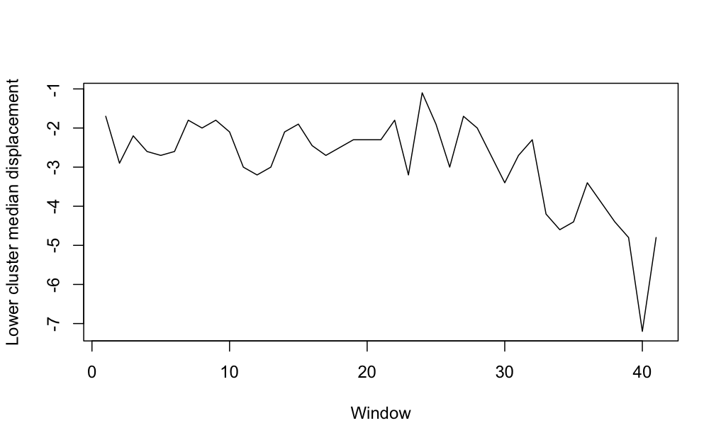

```r
# check threshold first
plot(
  medians_mat_w5[, 1],
  type = "l",
  xlab = "Window",
  ylab = "Lower cluster median displacement"
)
```

```r
head(medians_mat_w5)
tail(medians_mat_w5)
summary(medians_mat_w5)
```

```r
# threshold checking
thresholds <- c(-3, -3.5, -4, -4.5, -5)

sapply(
  thresholds,
  function(t) sum(medians_mat_w5[, "Lower_Cluster"] <= t)
)
```

##### Results checking:

```r
flagged_w5 <- colSums(status_mat_w5 == 1)

plot(
  flagged_w5,
  type = "l",
  xlab = "Sliding window",
  ylab = "Number of points with Status = 1",
  main = "W=5 K-means displacement"
)

summary(flagged_w5)
```

```r
which(medians_mat_w5[, "Lower_Cluster"] <= threshold_w5)
```

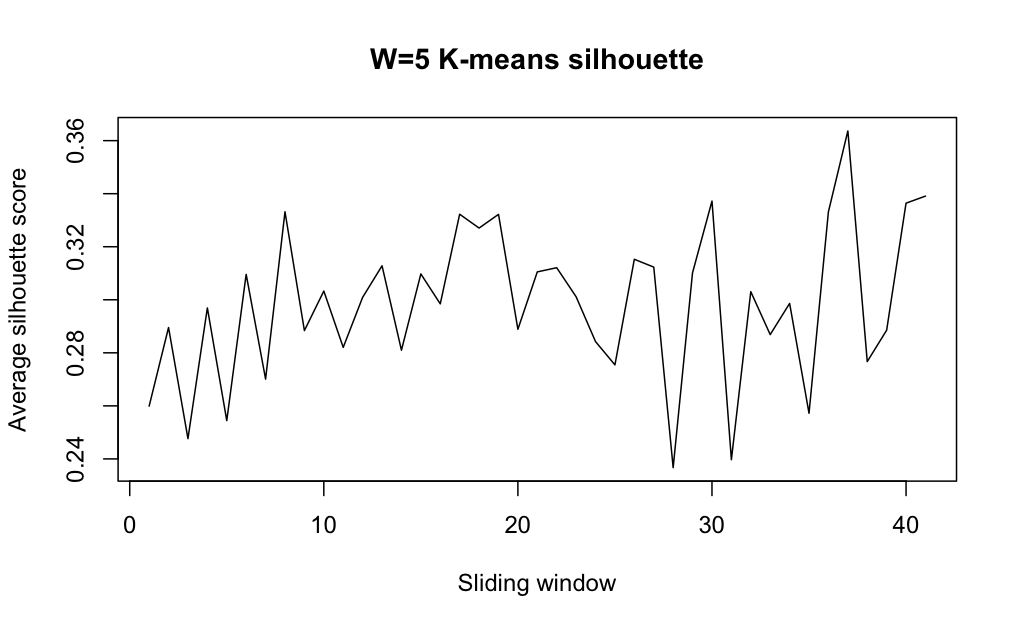

```r
# silhouette score
plot(
  silhouette_w5,
  type = "l",
  xlab = "Sliding window",
  ylab = "Average silhouette score",
  main = "W=5 K-means silhouette"
)
```

```r
summary(silhouette_w5)
```

```
   Min. 1st Qu.  Median    Mean 3rd Qu.    Max.
 0.2367  0.2821  0.3009  0.2984  0.3128  0.3636
```

```r
mean(silhouette_w5)
```

```
[1] 0.2984496
```

```r
# status changes
change_mat_w5 <- matrix(
  0,
  nrow = nrow(status_mat_w5),
  ncol = ncol(status_mat_w5)
)

change_mat_w5[, 2:ncol(change_mat_w5)] <-
  status_mat_w5[, 2:ncol(status_mat_w5)] !=
  status_mat_w5[, 1:(ncol(status_mat_w5) - 1)]

changes_w5 <- colSums(change_mat_w5)

change_prop_w5 <- colMeans(change_mat_w5)
```

```r
plot(
  change_prop_w5,
  type = "l",
  xlab = "Sliding window",
  ylab = "Proportion changing status",
  main = "W=5 temporal status changes"
)
```

##### Exporting:

```r
# converting to long: cluster

cluster_df_w5 <- as.data.frame(
  cluster_membership_mat_w5
)

cluster_df_w5$PointID <- cadia_info_sliding$PointID

clusters_long_w5 <- cluster_df_w5 %>%
  pivot_longer(
    cols = -PointID,
    names_to = "Date",
    values_to = "RawCluster"
  )

# converting to long: status
status_df_w5 <- as.data.frame(status_mat_w5)

status_df_w5$PointID <- cadia_info_sliding$PointID

status_long_w5 <- status_df_w5 %>%
  pivot_longer(
    cols = -PointID,
    names_to = "Date",
    values_to = "Status"
  )
```

```r
# combining clusters and status
cadia_kmeans_w5_results <-
  clusters_long_w5 %>%
  left_join(
    status_long_w5,
    by = c("PointID", "Date")
  ) %>%
  mutate(
    Date = sub("^cluster_", "", Date),
    Date = as.Date(Date, format = "%Y%m%d")
  ) %>%
  left_join(
    cadia_info_sliding,
    by = "PointID"
  )
```

```r
# exporting
write.csv(
  cadia_kmeans_w5_results,
  "../outputs/cadia_sw_km2_disp_w5_k2_threshold4.csv",
  row.names = FALSE
)
```

#### 5.1.2 K = 3

```r
# setup
window_size <- 5
k <- 3
threshold_1_w5 <- -5
threshold_2_w5 <- -7

n_pts_filtered <- nrow(cadia_D_filtered_sliding)
n_dates_filtered <- ncol(cadia_D_filtered_sliding)

n_iters_k3_w5 <- n_dates_filtered - window_size + 1

iter_dates_k3_w5 <- colnames(cadia_D_filtered_sliding)[
  window_size:n_dates_filtered
]

n_iters_k3_w5
```

```
[1] 41
```

```r
cluster_membership_k3_w5 <- matrix(
  NA,
  nrow = n_pts_filtered,
  ncol = n_iters_k3_w5
)

medians_k3_w5 <- matrix(
  NA,
  nrow = n_iters_k3_w5,
  ncol = 3
)

silhouette_k3_w5 <- numeric(n_iters_k3_w5)

colnames(medians_k3_w5) <- c(
  "Lower_Cluster",
  "Middle_Cluster",
  "Higher_Cluster"
)

date_names_k3_w5 <- paste0(
  "cluster_",
  sub("^D_", "", iter_dates_k3_w5)
)

colnames(cluster_membership_k3_w5) <-
  date_names_k3_w5
```

```r
# status
status_k3_w5 <- matrix(
  NA,
  nrow = n_pts_filtered,
  ncol = n_iters_k3_w5
)

colnames(status_k3_w5) <- date_names_k3_w5
```

```r
set.seed(1234)

for (i in window_size:n_dates_filtered) {

  start_idx <- i - window_size + 1
  iter <- i - window_size + 1

  # Extract W=5 window
  x <- cadia_D_filtered_sliding[
    , start_idx:i,
    drop = FALSE
  ]

  # Rebase each point so first date = 0
  x <- sweep(
    x,
    1,
    x[, 1],
    FUN = "-"
  )

  # K-means k=3
  km <- kmeans(
    x,
    centers = k,
    nstart = 20
  )

  # Save raw membership
  cluster_membership_k3_w5[, iter] <-
    km$cluster

  # Final displacement within this window
  latest_disp <- x[, ncol(x)]

  # Median final displacement of each raw K-means cluster
  cluster_medians <- tapply(
    latest_disp,
    km$cluster,
    median
  )

  cluster_status <- ifelse(
    cluster_medians <= threshold_2_w5,
    2,
    ifelse(
      cluster_medians <= threshold_1_w5,
      1,
      0
    )
  )

  status_k3_w5[, iter] <-
    cluster_status[km$cluster]

  # Sort ONLY for examining cluster behaviour
  medians_k3_w5[iter, ] <-
    sort(cluster_medians)

  # Silhouette
  sil <- cluster::silhouette(
    km$cluster,
    dist(x)
  )

  silhouette_k3_w5[iter] <-
    mean(sil[, "sil_width"])
}
```

```r
head(medians_k3_w5)
tail(medians_k3_w5)
summary(medians_k3_w5)
```

```r
table(status_k3_w5)
```

```r
date_names_k3_w5 <- paste0(
  "cluster_",
  sub("^D_", "", iter_dates_k3_w5)
)

colnames(cluster_membership_k3_w5) <- date_names_k3_w5
colnames(status_k3_w5) <- date_names_k3_w5
```

```r
# convert to long
cluster_df_k3_w5 <- as.data.frame(
  cluster_membership_k3_w5
)

cluster_df_k3_w5$PointID <-
  cadia_info_sliding$PointID

cluster_long_k3_w5 <- cluster_df_k3_w5 %>%
  pivot_longer(
    cols = -PointID,
    names_to = "Date",
    values_to = "RawCluster"
  )
```

```r
# convert to long
status_df_k3_w5 <- as.data.frame(
  status_k3_w5
)

status_df_k3_w5$PointID <-
  cadia_info_sliding$PointID

status_long_k3_w5 <- status_df_k3_w5 %>%
  pivot_longer(
    cols = -PointID,
    names_to = "Date",
    values_to = "Status"
  )
```

```r
# join all
cadia_disp_k3_w5 <- cluster_long_k3_w5 %>%
  left_join(
    status_long_k3_w5,
    by = c("PointID", "Date")
  ) %>%
  mutate(
    Date = sub("^cluster_", "", Date),
    Date = as.Date(Date, format = "%Y%m%d"),
    WindowSize = 5,
    K = 3,
    Threshold1 = -5,
    Threshold2 = -7
  ) %>%
  left_join(
    cadia_info_sliding,
    by = "PointID"
  )
```

```r
# checks
head(cadia_disp_k3_w5)
```

| PointID | Date | RawCluster | Status | WindowSize | K | Threshold1 | Threshold2 | lon | lat | coherence |
| --- | --- | --- | --- | --- | --- | --- | --- | --- | --- | --- |
| 1 | 2016-11-02 | 1 | 0 | 5 | 3 | -5 | -7 | 148.9938 | -33.49118 | 0.796 |
| 1 | 2016-11-14 | 1 | 0 | 5 | 3 | -5 | -7 | 148.9938 | -33.49118 | 0.796 |
| 1 | 2016-11-26 | 3 | 0 | 5 | 3 | -5 | -7 | 148.9938 | -33.49118 | 0.796 |
| 1 | 2016-12-08 | 3 | 0 | 5 | 3 | -5 | -7 | 148.9938 | -33.49118 | 0.796 |
| 1 | 2016-12-20 | 2 | 0 | 5 | 3 | -5 | -7 | 148.9938 | -33.49118 | 0.796 |
| 1 | 2017-01-01 | 2 | 0 | 5 | 3 | -5 | -7 | 148.9938 | -33.49118 | 0.796 |

```r
table(cadia_disp_k3_w5$Status)
```

```
    0     1     2
93208  5089  3998
```

```r
nrow(cadia_disp_k3_w5)
```

```
[1] 102295
```

```r
# export
write.csv(
  cadia_disp_k3_w5,
  "cadia_sw_disp_w5_k3_threshold5_7.csv",
  row.names = FALSE
)
```

### 5.2 Median Velocity version

#### 5.2.1 K = 2

```r
window_size <- 5
k <- 2

n_pts_filtered <- nrow(cadia_D_filtered_sliding)
n_dates_filtered <- ncol(cadia_D_filtered_sliding)

n_iters_vel_w5 <- n_dates_filtered - window_size + 1

iter_dates_vel_w5 <-
  colnames(cadia_D_filtered_sliding)[
    window_size:n_dates_filtered
  ]

cadia_all_dates <- as.Date(
  sub(
    "^D_",
    "",
    colnames(cadia_D_filtered_sliding)
  ),
  format = "%Y%m%d"
)
```

```r
cluster_membership_vel_w5 <- matrix(
  NA,
  nrow = n_pts_filtered,
  ncol = n_iters_vel_w5
)

status_vel_w5 <- matrix(
  NA,
  nrow = n_pts_filtered,
  ncol = n_iters_vel_w5
)

vel_medians_w5 <- matrix(
  NA,
  nrow = n_iters_vel_w5,
  ncol = 2
)

silhouette_vel_w5_old <- numeric(n_iters_vel_w5)

colnames(vel_medians_w5) <-
  c("Lower_Cluster", "Higher_Cluster")

date_names_vel_w5 <- paste0(
  "cluster_",
  sub("^D_", "", iter_dates_vel_w5)
)

colnames(cluster_membership_vel_w5) <- date_names_vel_w5
colnames(status_vel_w5) <- date_names_vel_w5
```

```r
# temporal clustering loop
set.seed(1234)

for (i in window_size:n_dates_filtered) {

  start_idx <- i - window_size + 1
  iter <- i - window_size + 1

  # W5 displacement trajectory
  x <- cadia_D_filtered_sliding[
    , start_idx:i,
    drop = FALSE
  ]

  # Rebase
  x <- sweep(x, 1, x[, 1], FUN = "-")

  # K-means on trajectory
  km <- kmeans(
    x,
    centers = k,
    nstart = 20
  )

  cluster_membership_vel_w5[, iter] <- km$cluster

  # Actual acquisition dates
  window_dates <- cadia_all_dates[start_idx:i]

  time_days <- as.numeric(
    window_dates - window_dates[1]
  )

  # Regression velocity for each point
  point_velocity <- apply(
    x,
    1,
    function(y) coef(lm(y ~ time_days))[2]
  ) * 365.25

  # Median velocity of each raw cluster
  cluster_velocity <- tapply(
    point_velocity,
    km$cluster,
    median
  )

  vel_medians_w5[iter, ] <-
    sort(cluster_velocity)

  # Fixed velocity status
  cluster_status <- ifelse(
    cluster_velocity <= velocity_threshold,
    1,
    0
  )

  status_vel_w5[, iter] <-
    cluster_status[km$cluster]

  # Silhouette
  sil <- cluster::silhouette(
    km$cluster,
    dist(x)
  )

  silhouette_vel_w5_old[iter] <-
    mean(sil[, "sil_width"])
}
```

```r
head(vel_medians_w5)
tail(vel_medians_w5)
summary(vel_medians_w5)

plot(
  vel_medians_w5[, "Lower_Cluster"],
  type = "l",
  xlab = "Window",
  ylab = "Lower cluster median velocity (mm/year)"
)

plot(
  silhouette_vel_w5,
  type = "l",
  xlab = "Window",
  ylab = "Average silhouette"
)
```

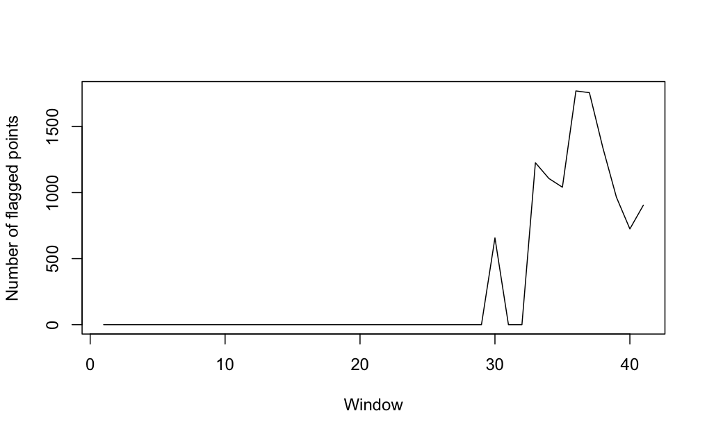

```r
# flagged pts
flagged_vel_w5 <- colSums(status_vel_w5 == 1)

plot(
  flagged_vel_w5,
  type = "l",
  xlab = "Window",
  ylab = "Number of flagged points"
)
```

##### Exporting:

```r
cluster_vel_df_w5 <- as.data.frame(
  cluster_membership_vel_w5
)

cluster_vel_df_w5$PointID <-
  cadia_info_sliding$PointID

cluster_vel_long_w5 <- cluster_vel_df_w5 %>%
  pivot_longer(
    cols = -PointID,
    names_to = "Date",
    values_to = "RawCluster"
  )
```

```r
status_vel_df_w5 <- as.data.frame(
  status_vel_w5
)

status_vel_df_w5$PointID <-
  cadia_info_sliding$PointID

status_vel_long_w5 <- status_vel_df_w5 %>%
  pivot_longer(
    cols = -PointID,
    names_to = "Date",
    values_to = "Status"
  )
```

```r
# combine
cadia_vel_w5_k2 <- cluster_vel_long_w5 %>%
  left_join(
    status_vel_long_w5,
    by = c("PointID", "Date")
  ) %>%
  mutate(
    Date = sub("^cluster_", "", Date),
    Date = as.Date(Date, format = "%Y%m%d")
  ) %>%
  left_join(
    cadia_info_sliding,
    by = "PointID"
  )
```

```r
# export
write.csv(
  cadia_vel_w5_k2,
  "../outputs/cadia_sw_vel_w5_k2.csv",
  row.names = FALSE
)
```

#### 5.2.2 K = 3

```r
# setup
window_size <- 5
k <- 3
threshold_1_vel_w5 <- -30
threshold_2_vel_w5 <- -50

n_pts_filtered <- nrow(cadia_D_filtered_sliding)
n_dates_filtered <- ncol(cadia_D_filtered_sliding)

n_iters_vel_k3_w5 <-
  n_dates_filtered - window_size + 1

iter_dates_vel_k3_w5 <-
  colnames(cadia_D_filtered_sliding)[
    window_size:n_dates_filtered
  ]

cadia_all_dates <- as.Date(
  sub(
    "^D_",
    "",
    colnames(cadia_D_filtered_sliding)
  ),
  format = "%Y%m%d"
)
```

```r
cluster_membership_vel_k3_w5 <- matrix(
  NA,
  nrow = n_pts_filtered,
  ncol = n_iters_vel_k3_w5
)

velocity_medians_k3_w5 <- matrix(
  NA,
  nrow = n_iters_vel_k3_w5,
  ncol = 3
)

silhouette_vel_k3_w5_old <-
  numeric(n_iters_vel_k3_w5)

colnames(velocity_medians_k3_w5) <- c(
  "Lower_Cluster",
  "Middle_Cluster",
  "Higher_Cluster"
)

date_names_vel_k3_w5 <- paste0(
  "cluster_",
  sub("^D_", "", iter_dates_vel_k3_w5)
)

colnames(cluster_membership_vel_k3_w5) <-
  date_names_vel_k3_w5
```

```r
status_vel_k3_w5 <- matrix(
  NA,
  nrow = n_pts_filtered,
  ncol = n_iters_vel_k3_w5
)

colnames(status_vel_k3_w5) <-
  date_names_vel_k3_w5
```

```r
# temporal clustering loop
set.seed(1234)

for (i in window_size:n_dates_filtered) {

  start_idx <- i - window_size + 1
  iter <- i - window_size + 1

  # Extract W5 displacement trajectory
  x <- cadia_D_filtered_sliding[
    , start_idx:i,
    drop = FALSE
  ]

  # Rebase first date to zero
  x <- sweep(
    x,
    1,
    x[, 1],
    FUN = "-"
  )

  # K-means on displacement trajectory
  km <- kmeans(
    x,
    centers = k,
    nstart = 20
  )

  cluster_membership_vel_k3_w5[, iter] <-
    km$cluster

  # Actual acquisition dates
  window_dates <-
    cadia_all_dates[start_idx:i]

  time_days <- as.numeric(
    window_dates - window_dates[1]
  )

  # Velocity for each point
  point_velocity <- apply(
    x,
    1,
    function(y) {
      coef(lm(y ~ time_days))[2]
    }
  )

  # mm/day -> mm/year
  point_velocity <-
    point_velocity * 365.25

  # Median velocity of each raw cluster
  cluster_velocity <- tapply(
    point_velocity,
    km$cluster,
    median
  )

  cluster_status <- ifelse(
    cluster_velocity <= threshold_2_vel_w5,
    2,
    ifelse(
      cluster_velocity <= threshold_1_vel_w5,
      1,
      0
    )
  )

  status_vel_k3_w5[, iter] <-
    cluster_status[km$cluster]

  # Sorted only for examining behaviour
  velocity_medians_k3_w5[iter, ] <-
    sort(cluster_velocity)

  # Silhouette
  sil <- cluster::silhouette(
    km$cluster,
    dist(x)
  )

  silhouette_vel_k3_w5_old[iter] <-
    mean(sil[, "sil_width"])
}
```

```r
# inspect vel for thresholds
head(velocity_medians_k3_w5)
```

```
     Lower_Cluster Middle_Cluster Higher_Cluster
[1,]     -31.80719      -0.304375       35.91625
[2,]     -52.63588     -13.434483       16.05841
[3,]     -27.89486      -9.279726       15.81265
[4,]     -30.43750      -5.174375       24.35000
[5,]     -30.89406      -7.000625       17.80594
[6,]     -37.43812     -10.348750       21.61062
```

```r
tail(velocity_medians_k3_w5)
```

```
      Lower_Cluster Middle_Cluster Higher_Cluster
[36,]     -53.57000     -11.870625       50.22187
[37,]     -49.61312      -4.565625       40.48188
[38,]     -54.48312      -3.043750       43.52562
[39,]     -49.91750       8.218125       44.28656
[40,]     -63.00562      10.348750       44.89531
[41,]     -55.39625       9.740000       47.17813
```

```r
summary(velocity_medians_k3_w5)
```

```
 Lower_Cluster    Middle_Cluster    Higher_Cluster
 Min.   :-63.01   Min.   :-13.434   Min.   : 9.74
 1st Qu.:-45.35   1st Qu.: -7.609   1st Qu.:17.81
 Median :-31.81   Median : -3.957   Median :23.44
 Mean   :-36.17   Mean   : -4.058   Mean   :27.54
 3rd Qu.:-28.61   3rd Qu.: -1.522   3rd Qu.:40.48
 Max.   :-20.39   Max.   : 10.349   Max.   :50.22
```

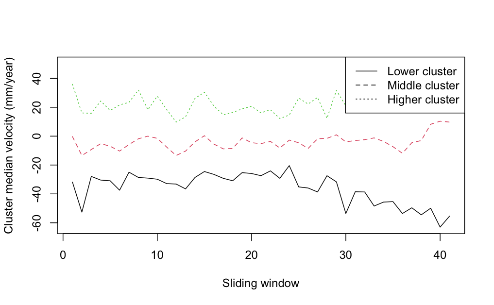

```r
matplot(
  velocity_medians_k3_w5,
  type = "l",
  lty = c(1, 2, 3),
  xlab = "Sliding window",
  ylab = "Cluster median velocity (mm/year)"
)

legend(
  "topright",
  legend = c(
    "Lower cluster",
    "Middle cluster",
    "Higher cluster"
  ),
  lty = c(1, 2, 3)
)
```

```r
lower_vel <- velocity_medians_k3_w5[, "Lower_Cluster"]

# -30 / -45
table(
  ifelse(lower_vel <= -45, 2,
         ifelse(lower_vel <= -30, 1, 0))
)
```

```
 0  1  2
16 14 11
```

```r
# -30 / -50
table(
  ifelse(lower_vel <= -50, 2,
         ifelse(lower_vel <= -30, 1, 0))
)
```

```
 0  1  2
16 19  6
```

**Results checking:**

```r
table(status_vel_k3_w5)
```

```
status_vel_k3_w5
    0     1     2
89113 10440  2742
```

```r
status0_vel_w5 <- colSums(status_vel_k3_w5 == 0)
status1_vel_w5 <- colSums(status_vel_k3_w5 == 1)
status2_vel_w5 <- colSums(status_vel_k3_w5 == 2)
```

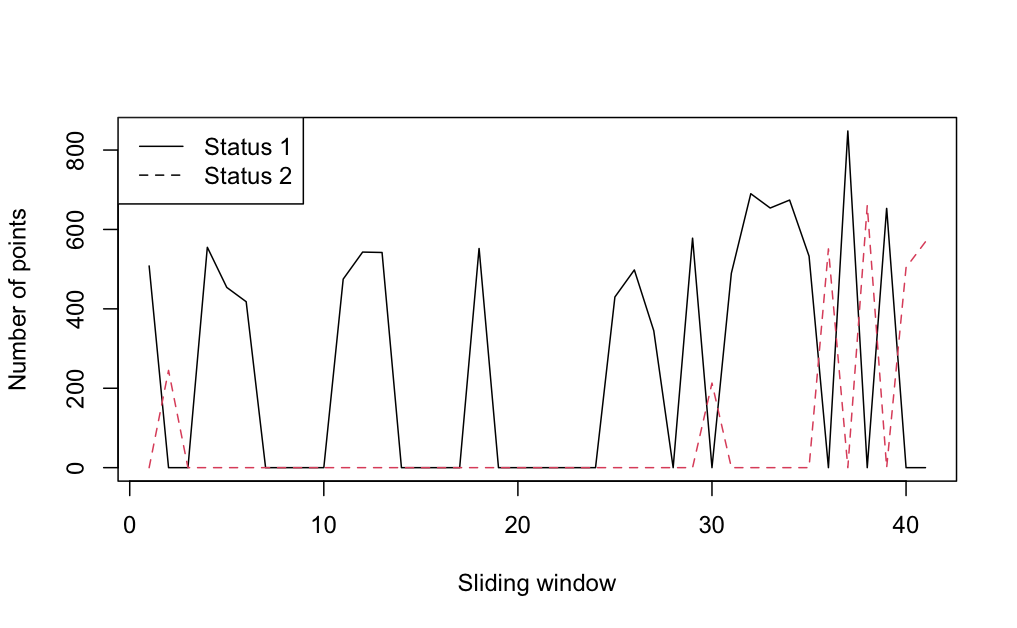

```r
matplot(
  cbind(
    status1_vel_w5,
    status2_vel_w5
  ),
  type = "l",
  lty = c(1, 2),
  xlab = "Sliding window",
  ylab = "Number of points"
)

legend(
  "topleft",
  legend = c("Status 1", "Status 2"),
  lty = c(1, 2)
)
```